# ClusterFoldSimilarity: comparing different single-cell experiments

Óscar González-Velasco

Division of Applied Bioinformatics, German Cancer Research Center DKFZ

31 August 2023

#### Package

ClusterFoldSimilarity 0.99.8

# 1 Installation

The package can be installed from R software using devtools:

```r
library(devtools)
install_github("OscarGVelasco/ClusterFoldSimilarity")
```

```r
library(ClusterFoldSimilarity)
```

# 2 Introduction

Comparing single-cell data across different datasets, samples and batches has demonstrated to be challenging. `ClusterFoldSimilarity` aims to solve the complexity of comparing different single-cell datasets by computing similarity scores between clusters (or user-defined groups) from any number of independent single-cell experiments, including different species and sequencing technologies. It accomplishes this by identifying analogous fold-change patterns across cell groups that share a common set of features (such as genes). Additionally, it selects and reports the top important features that have contributed to the observed similarity, serving as a tool for feature selection.

The output is a table that contains the similarity values for all the combinations of cluster-pairs from the independent datasets. `ClusterFoldSimilarity` also includes various plotting utilities to enhance the interpretability of the similarity scores.

### 2.0.1 Cross-species analysis and sequencing technologies (e.g.: Human vs Mouse, ATAC-Seq vs RNA-Seq)

`ClusterFoldSimilarity` is able to compare **any number** of independent experiments, including **different organisms**, making it useful for matching cell populations across different organisms, and thus, useful for inter-species analysis. Additionally, it can be used with **single-cell RNA-Seq data, single-cell ATAC-Seq data**, or more broadly, with continuous numerical data that shows changes in feature abundance across a set of common features between different groups.

### 2.0.2 Compatibility

It can be easily integrated on any existing single-cell analysis pipeline, and it is compatible with the most used single-cell objects: `Seurat` and `SingleCellExperiment`.

Parallel computing is available through the option parallel=TRUE which make use of BiocParallel.

# 3 Using ClusterFoldSimilarity to find similar clusters/cell-groups across datasets

Typically, `ClusterFoldSimilarity` will receive as input either a list of two or more `Seurat` or `SingleCellExperiment` objects, **containing processed data**: filtered and clustered/grouped by a phenotypic variable of our choice.

`ClusterFoldSimilarity` will obtain the **raw count data** from these objects ( `GetAssayData(assay, slot = "counts")` in the case of `Seurat`, or `counts()` for `SingleCellExperiment` object), and **cluster or label information** (using `Idents()` function from `Seurat`, or `colLabels()` for `SingleCellExperiment` ).

For the sake of illustration, we will employ the scRNAseq package, which contains numerous individual-cell datasets ready for download and encompassing samples from both human and mouse origins. In this example, we specifically utilize 2 human single-cell datasets obtained from the pancreas.

```r
library(Seurat)
library(scRNAseq)
library(dplyr)
# Human pancreatic single cell data 1
pancreas_muraro <- scRNAseq::MuraroPancreasData(ensembl = FALSE)
table(colData(pancreas_muraro)$label); dim(pancreas_muraro)
```

```
##
##      acinar       alpha        beta       delta        duct endothelial
##         219         812         448         193         245          21
##     epsilon mesenchymal          pp     unclear
##           3          80         101           4
```

```
## [1] 19059  3072
```

```r
pancreas_muraro <- pancreas_muraro[,rownames(colData(pancreas_muraro)[!is.na(colData(pancreas_muraro)$label),])]
colData(pancreas_muraro)$cell.type <- colData(pancreas_muraro)$label
rownames(pancreas_muraro) <- unlist(lapply(strsplit(rownames(pancreas_muraro),split = "__"),function(x)x[[1]]))
singlecell.1.seurat <- CreateSeuratObject(counts = counts(pancreas_muraro),meta.data = as.data.frame(colData(pancreas_muraro)))

# Human pancreatic single cell data 2
pancreas_baron <- scRNAseq::BaronPancreasData(which = "human",ensembl = FALSE)
table(colData(pancreas_baron)$label); dim(pancreas_baron)
```

```
##
##             acinar activated_stellate              alpha               beta
##                958                284               2326               2525
##              delta             ductal        endothelial            epsilon
##                601               1077                252                 18
##              gamma         macrophage               mast quiescent_stellate
##                255                 55                 25                173
##            schwann             t_cell
##                 13                  7
```

```
## [1] 20125  8569
```

```r
colData(pancreas_baron)$cell.type <- colData(pancreas_baron)$label
singlecell.2.seurat <- CreateSeuratObject(counts = counts(pancreas_baron),meta.data = as.data.frame(colData(pancreas_baron)))
```

Normalize and identify variable features for each dataset independently

*Note: these steps should be done tailored to each independent dataset, here we apply the same parameters for the sake of simplicity:*

```r
# Create a list with the unprocessed single-cell datasets
singlecell.object.list <- list(singlecell.1.seurat,singlecell.2.seurat)
# Apply the same processing to each dataset and return a list of single-cell analysis
singlecell.object.list <- lapply(X = singlecell.object.list, FUN = function(x){
x <- NormalizeData(x)
x <- FindVariableFeatures(x, selection.method = "vst", nfeatures = 2000)
x <- ScaleData(x,features = VariableFeatures(x))
x <- RunPCA(x, features = VariableFeatures(object = x))
x <- FindNeighbors(x, dims = seq(16))
x <- FindClusters(x, resolution = 0.4)
})
```

```
## Modularity Optimizer version 1.3.0 by Ludo Waltman and Nees Jan van Eck
##
## Number of nodes: 2126
## Number of edges: 74710
##
## Running Louvain algorithm...
## Maximum modularity in 10 random starts: 0.9223
## Number of communities: 10
## Elapsed time: 0 seconds
## Modularity Optimizer version 1.3.0 by Ludo Waltman and Nees Jan van Eck
##
## Number of nodes: 8569
## Number of edges: 301790
##
## Running Louvain algorithm...
## Maximum modularity in 10 random starts: 0.9377
## Number of communities: 14
## Elapsed time: 0 seconds
```

Once we have all of our single-cell datasets analyzed independently, we can compute the similarity values. `clusterFoldSimilarity()` takes as arguments:

- `sceList`: a list of single-cell objects (mandatory) either of class `Seurat` or of class `SingleCellExperiment`.
- `sampleNames`: vector with names for each of the datasets. If not set the datasets will be named in the given order as: *1, 2, …, N*.
- `topN`: the top n most similar clusters/groups to report for each cluster/group (default: `1`, the top most similar cluster). If set to `Inf` it will return the values from all the possible cluster-pairs.
- `topNFeatures`: the top *n* features (e.g.: genes) that contribute to the observed similarity between the pair of clusters (default: `1`, the top contributing gene). If a negative number, the tool will report the *n* most dissimilar features.
- `nSubsampling`: number of subsamplings (1/3 of cells on each iteration) at group level for calculating the fold-changes (default: `15`). At start, the tool will report a message with the recommended number of subsamplings for the given data (average n of subsamplings needed to observe all cells).
- `parallel`: whether to use parallel computing with multiple threads or not (default: `FALSE`). If we want to use a specific single-cell experiment for annotation (from which we know a ground-truth label, e.g. cell type, cell cycle, treatment… etc.), we can use that label to directly compare the single-cell datasets.

Here we will use the annotated pancreas cell-type labels from the dataset 1 to illustrate how to match clusters to cell-types using a reference dataset:

```r
# Assign cell-type annotated from the original study to the cell labels:
Idents(singlecell.object.list[[1]]) <- factor(singlecell.object.list[[1]][[]][,"cell.type"])

library(ClusterFoldSimilarity)
similarity.table <- clusterFoldSimilarity(sceList=singlecell.object.list, sampleNames = c("human","human.NA"),
                                          topN=1, nSubsampling = 24)
```

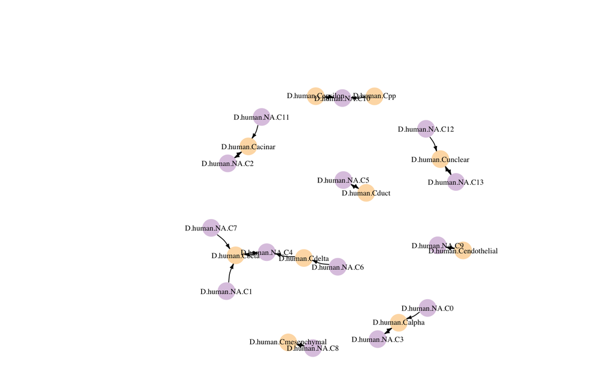

```r
head(similarity.table)
```

```
##             similarityValue  sem    w datasetL    clusterL datasetR clusterR
## acinar             50.39053 0.04 6.82    human      acinar human.NA        2
## alpha              34.59490 0.02 6.51    human       alpha human.NA        3
## beta               33.84496 0.01 6.58    human        beta human.NA        4
## delta              29.30908 0.01 6.28    human       delta human.NA        4
## duct               33.35420 0.01 6.41    human        duct human.NA        5
## endothelial        45.64004 0.02 7.01    human endothelial human.NA        9
##             topFeatureConserved geneScore
## acinar                    REG1A 50.427213
## alpha                       GCG 34.122804
## beta                        INS 30.337947
## delta                     PCSK1  7.573988
## duct                       SPP1 13.135512
## endothelial               PLVAP 18.286168
```

By default, `clusterFoldSimilarity()` will plot a graph network that visualizes the connections between the clusters from the different datasets using the similarity table that has been obtained. The arrows point in the direction of the similarity (datasetL:clusterL -> datasetR:clusterR); it can be useful for identifying relationships between groups of clusters and cell-populations that tend to be more similar. The graph plot can also be obtained by using the function `plotClustersGraph()` from this package, using as input the similarity table.

In this example, as we have information regarding cell-type labels, we can check how the cell types match by calculating the most abundant cell type on each of the similar clusters:

```r
type.count <- singlecell.object.list[[2]][[]] %>%
  group_by(seurat_clusters) %>%
  count(cell.type) %>%
  arrange(desc(n), .by_group = TRUE) %>%
  filter(row_number()==1)

cbind.data.frame(type.count,
                 matched.type = rep(table(type.count$seurat_clusters), x = similarity.table[similarity.table$datasetL == "human.NA",]$clusterR))
```

```
##    seurat_clusters          cell.type    n matched.type
## 1                0              alpha 1308        alpha
## 2                1               beta 1022         beta
## 3                2             acinar  927       acinar
## 4                3              alpha  967        alpha
## 5                4               beta  958         beta
## 6                5             ductal  817         duct
## 7                6              delta  586        delta
## 8                7               beta  494         beta
## 9                8 activated_stellate  283  mesenchymal
## 10               9        endothelial  250  endothelial
## 11              10              gamma  211      epsilon
## 12              11             ductal  174       acinar
## 13              12         macrophage   55      unclear
## 14              13             ductal   77      unclear
```

## 3.1 Retrieving the top-n similarities

If we suspect that clusters could be related with more than one cluster of other datasets, we can retrieve the top n similarities for each cluster:

```r
# Retrieve the top 3 similar cluster for each of the clusters:
similarity.table.3top <- clusterFoldSimilarity(sceList=singlecell.object.list, topN=3,
                                             sampleNames = c("human","human.NA"), nSubsampling = 24)
```

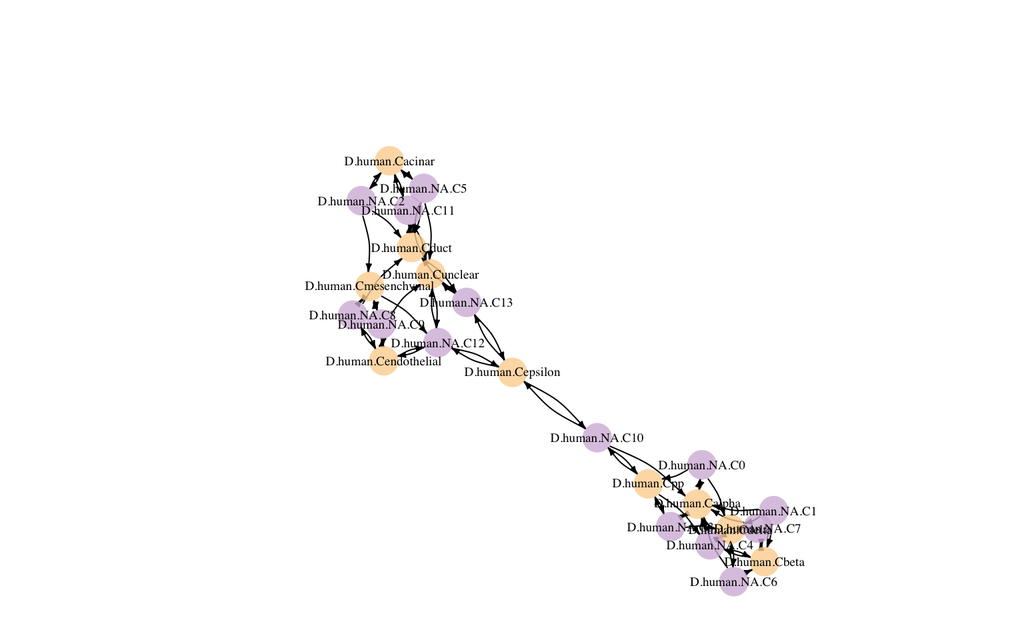

```r
head(similarity.table.3top)
```

```
##           similarityValue  sem    w datasetL clusterL datasetR clusterR
## acinar.3         50.27570 0.04 6.84    human   acinar human.NA        2
## acinar.12        42.76349 0.03 6.65    human   acinar human.NA       11
## acinar.6         26.76853 0.01 5.94    human   acinar human.NA        5
## alpha.4          34.47803 0.02 6.50    human    alpha human.NA        3
## alpha.1          31.25479 0.02 6.33    human    alpha human.NA        0
## alpha.5          29.93044 0.01 6.38    human    alpha human.NA        4
##           topFeatureConserved geneScore
## acinar.3                REG1A 49.727196
## acinar.12               REG3A 40.431410
## acinar.6             SERPINA3 14.144226
## alpha.4                   GCG 33.834157
## alpha.1                   GCG 29.992194
## alpha.5                   INS  8.058919
```

## 3.2 Obtaining the top-n feature markers

If we are interested on the features that contribute the most to the similarity, we can retrieve the top n features:

```r
# Retrieve the top 5 features that contribute the most to the similarity between each pair of clusters:
similarity.table.5top.features <- clusterFoldSimilarity(sceList=singlecell.object.list, topNFeatures=5, nSubsampling = 24)
```

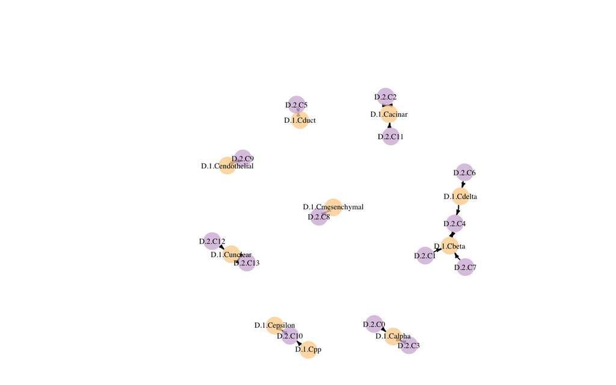

```r
head(similarity.table.5top.features, n=10)
```

```
##           similarityValue  sem    w datasetL clusterL datasetR clusterR
## acinar.11        50.18319 0.04 6.82        1   acinar        2        2
## acinar.12        50.18319 0.04 6.82        1   acinar        2        2
## acinar.13        50.18319 0.04 6.82        1   acinar        2        2
## acinar.14        50.18319 0.04 6.82        1   acinar        2        2
## acinar.15        50.18319 0.04 6.82        1   acinar        2        2
## alpha.16         34.49170 0.02 6.51        1    alpha        2        3
## alpha.17         34.49170 0.02 6.51        1    alpha        2        3
## alpha.18         34.49170 0.02 6.51        1    alpha        2        3
## alpha.19         34.49170 0.02 6.51        1    alpha        2        3
## alpha.20         34.49170 0.02 6.51        1    alpha        2        3
##           topFeatureConserved geneScore
## acinar.11               REG1A  50.56400
## acinar.12               CTRB2  46.65210
## acinar.13               REG1B  46.30476
## acinar.14               PRSS1  45.14041
## acinar.15              CELA3A  40.36778
## alpha.16                  GCG  33.88686
## alpha.17                  TTR  22.29361
## alpha.18                 CHGB  13.28128
## alpha.19                PCSK2  11.74380
## alpha.20               TM4SF4  11.52553
```

## 3.3 Retrieving all the similarity values and plotting a similarity heatmap

Sometimes it is useful to retrieve all the similarity values for downstream analysis (e.g. identify more than one cluster that is similar to a cluster of interest, finding the most dissimilar clusters, etc). To obtain all the values, we need to specify `topN=Inf`:

```r
similarity.table.all.values <- clusterFoldSimilarity(sceList=singlecell.object.list, sampleNames = c("human","human.NA"), topN=Inf)
```

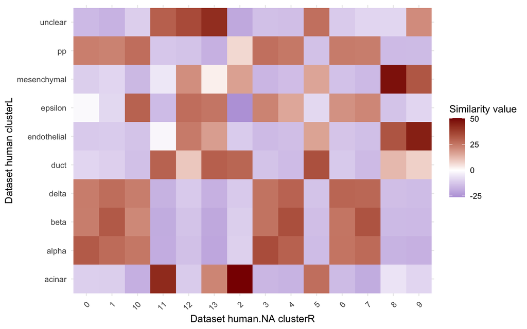

```r
dim(similarity.table.all.values)
```

```
## [1] 280   9
```

For downstream analysis of the similarities, it can be convenient to create a matrix with all the scores from the comparison of two datasets:

```r
library(dplyr)
dataset1 <- "human"
dataset2 <- "human.NA"
similarity.table.2 <- similarity.table.all.values %>%
filter(datasetL == dataset1 & datasetR == dataset2) %>%
arrange(desc(as.numeric(clusterL)), as.numeric(clusterR))
cls <- unique(similarity.table.2$clusterL)
cls2 <- unique(similarity.table.2$clusterR)
similarity.matrix.all <- t(matrix(similarity.table.2$similarityValue, ncol=length(unique(similarity.table.2$clusterL))))
rownames(similarity.matrix.all) <- cls
colnames(similarity.matrix.all) <- cls2
similarity.matrix.all
```

```
##                      0         1          2          3          4          5
## acinar      -10.778505  31.34820  23.824174  24.006333  -9.298049 -12.083066
## alpha       -10.599444 -11.47518  -8.764731  -9.303044  22.905941 -17.549123
## beta          6.617920 -19.98046 -16.460268  34.533357  25.961013  26.002318
## delta        33.909341  29.54952 -15.203498 -14.662303  15.663055 -14.898104
## duct         -8.665446  16.01532 -13.919161  26.669199 -15.416092  25.839788
## endothelial -19.130665  27.75257  32.954694  28.510081 -15.521158 -14.551334
## epsilon      12.371020  32.75717 -13.676588  48.497206 -15.643434  -9.119929
## mesenchymal -15.439755  20.94079 -18.229105  25.162279  21.669102  23.782875
## pp          -19.170211 -17.68355  29.703291  -1.890348 -15.331464  -5.441466
## unclear      27.076625  20.51570 -13.680160  34.887744  22.185116 -20.475578
##                      6         7         8          9         10         11
## acinar       -1.419002 -11.14312  23.67350 -15.864382 -11.058165  27.567988
## alpha        50.372060 -10.48405 -11.15313 -12.065229  28.795495 -11.530461
## beta        -13.550186 -15.63813  22.59147 -16.796390  26.625855 -14.277074
## delta        25.016637 -14.75070  26.82326 -14.993217 -14.885227 -13.530663
## duct         25.548639  28.94218 -12.24735 -13.220783  19.778092 -13.835019
## endothelial  21.917669 -15.94017  23.87148  -9.385069  -6.066928 -17.456965
## epsilon      -9.211890 -17.79924 -15.86825 -15.035359   8.038072  45.386340
## mesenchymal -14.145027 -13.57733  29.65106 -16.255034  27.086561 -10.970661
## pp          -12.618246  30.28262 -11.64702 -14.309750 -13.547243 -12.068066
## unclear     -19.983967 -17.83668  30.21019  17.439103  25.499114   2.705813
##                     12        13
## acinar       31.620782  27.23373
## alpha       -26.149198  16.96562
## beta        -17.375964  29.84155
## delta        33.558480  16.37401
## duct         24.301103 -11.78438
## endothelial -15.727043 -14.73104
## epsilon      -9.329170  32.39865
## mesenchymal  42.742458 -18.97677
## pp            9.581795  24.48930
## unclear     -17.886377  41.85047
```

# 4 Using ClusterFoldSimilarity across species and numerous datasets:

`ClusterFoldSimilarity` can compare **any number** of independent studies, including **different organisms**, making it useful for inter-species analysis. Also, it can be used on different sequencing data technologies: e.g.: compare single-cell **ATAC-Seq VS RNA-seq**.

In this example, we are going to add a pancreas single-cell dataset from **Mouse** to the 2 existing ones from **Human** that we have processed in the previous steps.

```r
# Mouse pancreatic single cell data
pancreas_baron_mm <- scRNAseq::BaronPancreasData(which = "mouse",ensembl = FALSE)
table(colData(pancreas_baron_mm)$label); dim(pancreas_baron_mm)
```

```
##
## activated_stellate              alpha             B_cell               beta
##                 14                191                 10                894
##              delta             ductal        endothelial              gamma
##                218                275                139                 41
##       immune_other         macrophage quiescent_stellate            schwann
##                  8                 36                 47                  6
##             T_cell
##                  7
```

```
## [1] 14878  1886
```

```r
colData(pancreas_baron_mm)$cell.type <- colData(pancreas_baron_mm)$label
# Translate mouse gene ids to human ids
# *for the sake of simplicity we are going to transform to uppercase all mouse gene names
rownames(pancreas_baron_mm) <- toupper(rownames(pancreas_baron_mm))
# Create seurat object
singlecell.3.seurat <- CreateSeuratObject(counts = counts(pancreas_baron_mm),meta.data = as.data.frame(colData(pancreas_baron_mm)))

# We append the single-cell object to our list
singlecell.object.list[[3]] <- singlecell.3.seurat
```

Now, we process the new single-cell dataset from mouse, and we calculate the similarity scores between the 3 independent datasets.

This time we will make use of the option parallel=TRUE:

```r
x <- singlecell.object.list[[3]]
x <- NormalizeData(x)
x <- FindVariableFeatures(x, selection.method = "vst", nfeatures = 2000)
x <- ScaleData(x,features = VariableFeatures(x))
x <- RunPCA(x, features = VariableFeatures(object = x))
x <- FindNeighbors(x, dims = seq(16))
x <- FindClusters(x, resolution = 0.4)
```

```
## Modularity Optimizer version 1.3.0 by Ludo Waltman and Nees Jan van Eck
##
## Number of nodes: 1886
## Number of edges: 63632
##
## Running Louvain algorithm...
## Maximum modularity in 10 random starts: 0.9145
## Number of communities: 9
## Elapsed time: 0 seconds
```

```r
singlecell.object.list[[3]] <- x

# We use the cell labels as a second reference, but we can also use the cluster labels if our interest is to match clusters
Idents(singlecell.object.list[[3]]) <- factor(singlecell.object.list[[3]][[]][,"cell.type"])

# We subset the most variable genes in each experiment
singlecell.object.list.variable <- lapply(singlecell.object.list, function(x){x[VariableFeatures(x),]})

similarity.table.human.mouse <- clusterFoldSimilarity(sceList = singlecell.object.list.variable,
                                                        sampleNames = c("human","human.NA","mouse"),
                                                        topN = 1,
                                                        nSubsampling = 24,
                                                        parallel = TRUE)
```

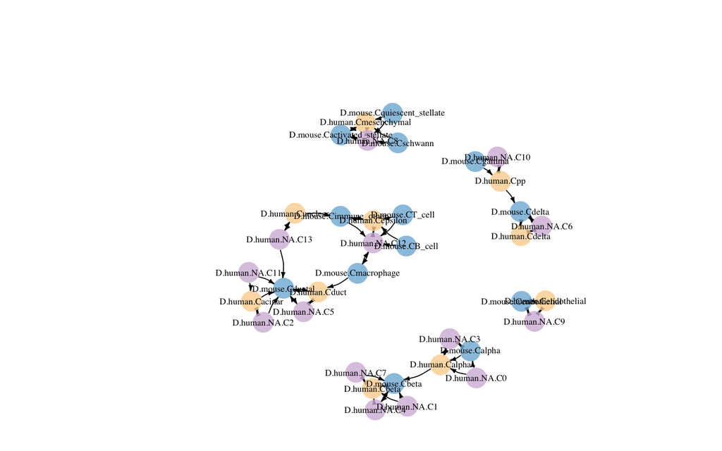

We can compute and visualize with a heatmap all the similarities for each cluster/group of cells from the 3 datasets using `topN=Inf`. Additionally, we can use the function `similarityHeatmap()` from this package to plot the heatmap with the datasets in a different order, or just plot the 2 datasets we are interested in.

```r
similarity.table.human.mouse.all <- clusterFoldSimilarity(sceList = singlecell.object.list.variable,
                                                          sampleNames = c("human","human.NA","mouse"),
                                                          topN = Inf,
                                                          nSubsampling = 24,
                                                          parallel = TRUE)
```

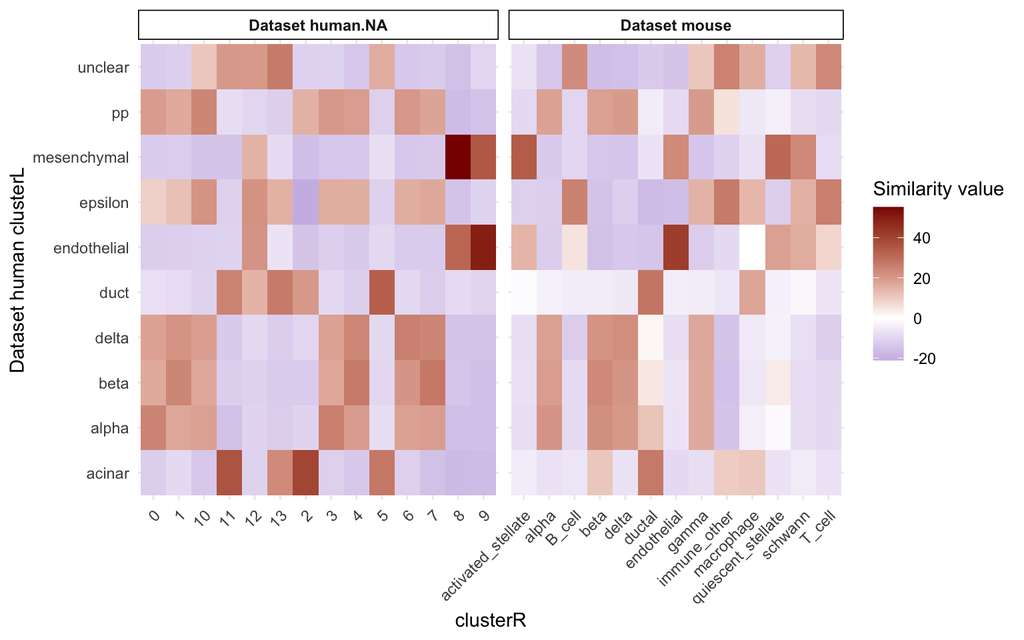

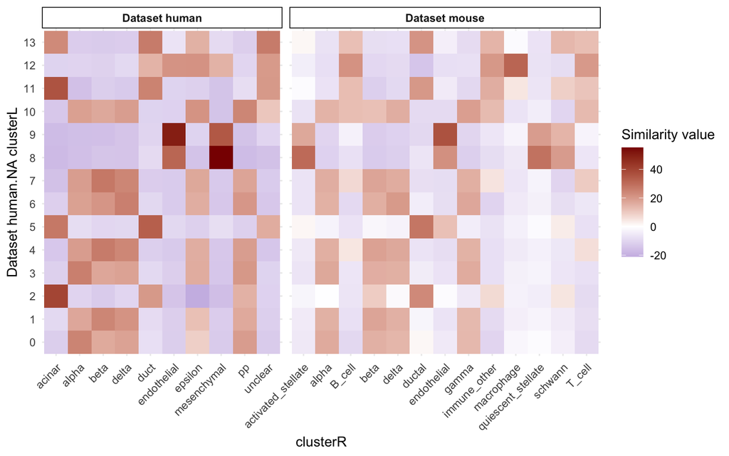

```r
# We can select which dataset to plot in the Y-axis:
ClusterFoldSimilarity::similarityHeatmap(similarityTable=similarity.table.human.mouse.all, mainDataset="human.NA")
```

# 5 Similarity score calculation

`ClusterFoldSimilarity` does not need to integrate the data, or apply any batch correction techniques across the datasets that we aim to analyze, which makes it less prone to data-loss or noise. The similarity value is based on the fold-changes between clusters/groups of cells defined by the user. These fold-changes from different independent datasets are first computed using a Bayesian approach, we calculate this fold-change distribution using a permutation analysis that srink the fold-changes with no biological meaning. These differences in abundance are then combined using a pairwise dot product approach, after adding these feataure contributions and applying a fold-change concordance weight, a similarity value is obtained for each of the clusters of each of the datasets present.